# Tarea_2

Autor/a

Daniela Moya Víquez

# INTRODUCCION

## INDICE DE CALOR (IC)

El índice de calor es la sensación térmica que experimenta el cuerpo al combinar la temperatura del aire y la humedad relativa, se necesitan dos varibles principales(Decreto N.º 39147-S-TSS, 2015):

1. Temperatura del aire (en grados Celsius o Fahrenheit).
2. Humedad relativa (en porcentaje %).

De conformidad con el estudio realizado por la Caja Costarricense de Seguro Social, denominado *“Factores Asociados a Enfermedad Renal Crónica, Región Chorotega año 2014”*, se concluye que en Costa Rica, la ERCnT, tiende a ser mayor en hombres jóvenes que se dedican a trabajos físicos y se concentran en comunidades de la provincia de Guanacaste (Caja Costarricense de Seguro Social [CCSS], 2014).

Este documento permite estimar el **índice de calor** con una base de datos que incluye **las varibles de temperatura y humedad** en este caso de forma exclusiva para la ciudad de Liberia Guanacaste tomando de referencia la **Estación del Aeropuerto del Liberia**, a partir de los datos brindados por Climate Hazards Group InfraRed Precipitation with Station data [CHIRPS] y descargados de las bases de datos disponibles en **El blog de Franz** (Leonardo, s. f.)

Cabe mencionar que para obtener el índice de calor se debe tomar de referencia la siguiente imagen:

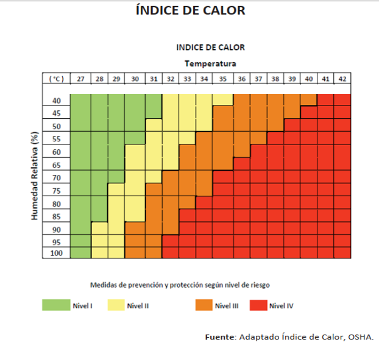

Con la información anterior se desea conocer:

# IMPORTACIÓN Y PREPARACIÓN DE LOS DATOS

## CARGA DE DATOS

```r
library(tidyverse)
library(dplyr)
library(plotly)
library(DT)
i_calor <- read_csv("https://raw.githubusercontent.com/dani10movister-bot/tarea-02/refs/heads/main/bd_tarea-02_3.csv")

i_calor
```

```
# A tibble: 12 × 4
    year month t_mean hr_mean
   <dbl> <dbl>  <dbl>   <dbl>
 1  2025     1   26.2    68.0
 2  2025     2   27.3    71.4
 3  2025     3   28.5    77.1
 4  2025     4   28.9    83.1
 5  2025     5   28.5    88.4
 6  2025     6   26.3    89.7
 7  2025     7   26.8    88.6
 8  2025     8   27.3    83.9
 9  2025     9   26.1    78.6
10  2025    10   25.1    72.8
11  2025    11   25.8    67.7
12  2025    12   26.2    66.3
```

```r
#head(i_calor)
```

## DESCRIPCIÓN DE DATOS

```r
glimpse(i_calor)
```

```
Rows: 12
Columns: 4
$ year    <dbl> 2025, 2025, 2025, 2025, 2025, 2025, 2025, 2025, 2025, 2025, 20…
$ month   <dbl> 1, 2, 3, 4, 5, 6, 7, 8, 9, 10, 11, 12
$ t_mean  <dbl> 26.23874, 27.32039, 28.50100, 28.91237, 28.53026, 26.26350, 26…
$ hr_mean <dbl> 67.96774, 71.42857, 77.09677, 83.10000, 88.41935, 89.70000, 88…
```

```r
dim(i_calor)
```

```
[1] 12  4
```

# DT

## TABLA DE DATOS INTERACTIVA

```r
i_calor |>
  datatable(
    rownames = FALSE,
    options = list(
      pageLength = 10,
      autoWidth = TRUE,
      language = list(url = "https://cdn.datatables.net/plug-ins/1.10.11/i18n/Spanish.json")),
    caption = htmltools::tags$caption(
      style = 'caption-side: top; text-align: center; font-weight: bold;',
      'Tabla 1: Datos de temperatura y humedad (CHIRPS) - Enero a Diciembre 2025'
    )
  )
```

| year | month | t_mean | hr_mean |
| --- | --- | --- | --- |
| 2025 | 1 | 26.23874194 | 67.96774194 |
| 2025 | 2 | 27.32039286 | 71.42857143 |
| 2025 | 3 | 28.501 | 77.09677419 |
| 2025 | 4 | 28.91236667 | 83.1 |
| 2025 | 5 | 28.53025806 | 88.41935484 |
| 2025 | 6 | 26.2635 | 89.7 |
| 2025 | 7 | 26.84445161 | 88.61290323 |
| 2025 | 8 | 27.29380645 | 83.87096774 |
| 2025 | 9 | 26.103 | 78.56666667 |
| 2025 | 10 | 25.05493548 | 72.83870968 |

[output cut: 2 more lines]

# TRANSFORMACIÓN DE DATOS

## MESES CON TEMPERATURA > 28 °C y %HUMEDAD RELATIVA > 75 %

```r
filter(i_calor, t_mean > 28 & hr_mean > 75)
```

```
# A tibble: 3 × 4
   year month t_mean hr_mean
  <dbl> <dbl>  <dbl>   <dbl>
1  2025     3   28.5    77.1
2  2025     4   28.9    83.1
3  2025     5   28.5    88.4
```

La tabla interativa permite observa el comportamiento de las variales detemperatura y humedad relativa para cada uno de los meses del periodo 2025. Permite ordenar cada variable en orden ascendente o descente, según corresponda.

Meses del año 2025 con el % de humedad relativa ideal, implica que se percibe más fresca la temperatura.No existen para el periodo 2025.

```r
filter (i_calor, hr_mean < 60)
```

```
# A tibble: 0 × 4
# ℹ 4 variables: year <dbl>, month <dbl>, t_mean <dbl>, hr_mean <dbl>
```

```r
filter (i_calor, t_mean > 28 & hr_mean > 80)
```

```
# A tibble: 2 × 4
   year month t_mean hr_mean
  <dbl> <dbl>  <dbl>   <dbl>
1  2025     4   28.9    83.1
2  2025     5   28.5    88.4
```

## DISTRIBUCIÓN DE TEMPERATURA POR MES EN LIBERIA,2025

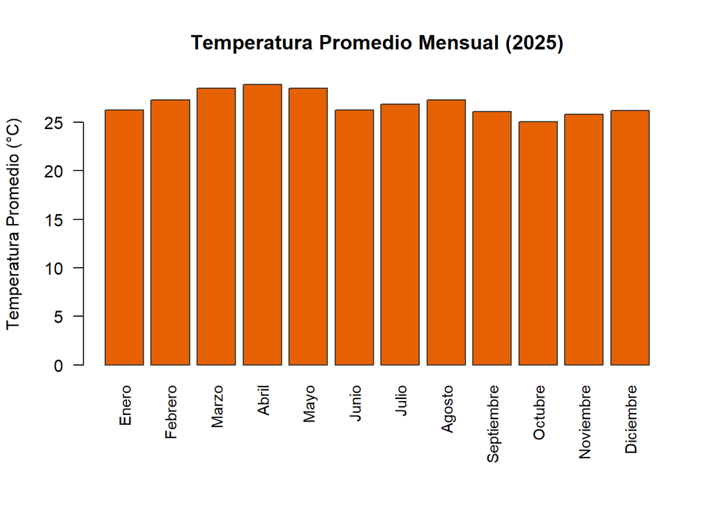

```r
nombres_meses <- c("Enero", "Febrero", "Marzo", "Abril", "Mayo", "Junio",
                   "Julio", "Agosto", "Septiembre", "Octubre", "Noviembre", "Diciembre")

par(mar = c(7, 4, 4, 2) + 0.1)

bp <- barplot(
  height = i_calor$t_mean,
  names.arg = nombres_meses,
  col = "#e66101",
  border = "gray20",
  ylim = c(0, 29),
  ylab = "Temperatura Promedio (°C)",
  main = "Temperatura Promedio Mensual (2025)",
  las = 2,       # Rota las etiquetas de los meses verticalmente
  cex.names = 0.9
)
```

## DISTRIBUCIÓN MENSUAL DE %HR PARA EL PERIODO 2025

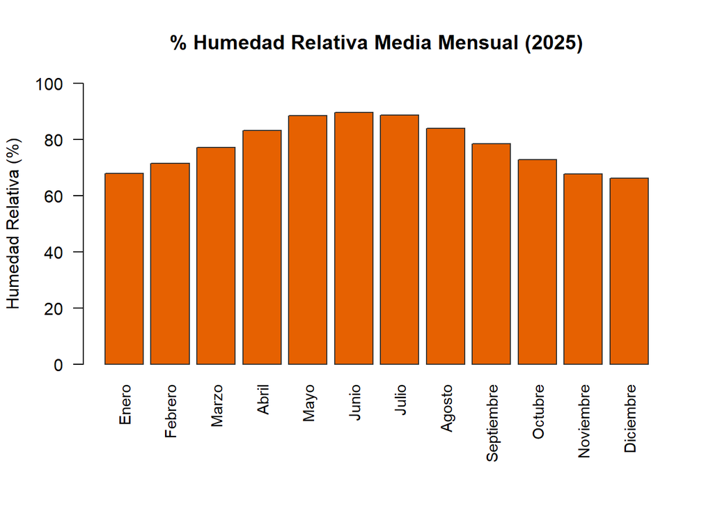

```r
nombres_meses <- c("Enero", "Febrero", "Marzo", "Abril", "Mayo", "Junio",
                   "Julio", "Agosto", "Septiembre", "Octubre", "Noviembre", "Diciembre")

par(mar = c(7, 4, 4, 2) + 0.1)

bp <- barplot(
  height = i_calor$hr_mean,
  names.arg = nombres_meses,
  col = "#e66101",
  border = "gray20",
  ylim = c(0, 100),
  ylab = "Humedad Relativa (%)",
  main = "% Humedad Relativa Media Mensual (2025)",
  las = 2,       # Rota las etiquetas de los meses verticalmente
  cex.names = 0.9

  )
```

# GRAFICO INTERACTIVO CON VARIABLES DE TEMPERATURA Y HUMEDAD RELATIVA

```r
meses <- c("Enero", "Febrero", "Marzo", "Abril", "Mayo", "Junio",
           "Julio", "Agosto", "Septiembre", "Octubre", "Noviembre", "Diciembre")
i_calor$mes_nombre <- factor(i_calor$month, levels = 1:12, labels = meses)


plot_ly(
  data = i_calor,
  x = ~t_mean,
  y = ~hr_mean,
  text = ~mes_nombre,
  type = "scatter",
  mode = "markers+text",
  textposition = "top center",
  marker = list(size = 12, color = ~t_mean, colorscale = "YlOrRd", showscale = TRUE)
) %>%
  layout(
    title = "Relación Temperatura promedio vs. Humedad Relativa promedio (2025)",
    xaxis = list(title = "Temperatura Promedio(°C)"),
    yaxis = list(title = "Humedad Relativa Promedio (%)")
  )
```

[interactive chart not shown]

# REFERENCIAS BIBLIOGRÁFICAS

Costa Rica. Presidencia de la República, Ministerio de Salud & Ministerio de Trabajo y Seguridad Social. (2015, 23 de setiembre). Decreto Ejecutivo Nº 39147-S-TSS: Reglamento para la contratación de servicios de medicina del trabajo y seguridad e higiene en el trabajo. La Gaceta, (185), Alcance 75. http://www.pgrweb.go.cr/scij/Busqueda/Normativa/Normas/nrm_texto_completo.aspx?param1=NRTC&nValor1=1&nValor2=80290

Caja Costarricense de Seguro Social. (2014). Factores asociados a Enfermedad Renal Crónica, Región Chorotega: Informe final de resultados. Ministerio de Salud de Costa Rica. https://www.ministeriodesalud.go.cr/index.php/biblioteca-de-archivos-left/documentos-ministerio-de-salud/tecno-ciencia/inventario-de-enfermedad-renal-cronica-no-tradicional-ercnt/estudios-de-ercnt-situacion-de-la-problematica-en-costa-rica/9654-factores-asociados-a-enfermedad-renal-cronica-region-chorotega-ccss/file

Leonardo, F. (s. f.). CHIRPS [Archivo temático de blog]. Acolita: Geomática y Medio Ambiente. Recuperado el 27 de octubre de 2026, de https://acolita.com/tag/chirps/

# DECLARACIÓN DE USO DE IA

Se utilizó la herramienta Gemini para generar una primera versión de la función de descarga de datos y dar formato APA 7 a las referencias. Los resultados fueron revisados, verificados y adaptados por la persona autora.